# CSC180_Transfer_learning_project_on_cifar_10_(proj3_version)

## Mini-Project 3: Computer Vision using GPU and Transfer Learning

#### CSC 180 Intelligent Systems (Fall 2019)

#### Dr. Haiquan Chen, California State University, Sacramento

```python
# Insert your name, your id, course title, assignment id, and due date here as comment

'''
Group Members:
Ronngguang Ou (219817313)
John Leonardo (216649967)
Manuel Herrera (219721880)

CSC 180 Intelligent Systems
Mini-Project 3
Friday, October 25, 2019

'''
```

```
'\nGroup Members:\nRonngguang Ou (219817313)\nJohn Leonardo (216649967)\nManuel Herrera (219721880)\n\nCSC 180 Intelligent Systems\nMini-Project 3\nFriday, October 25, 2019\n\n'
```

## Helpful Functions for Tensorflow (Little Gems)

The following functions will be used with TensorFlow to help preprocess the data. They allow you to build the feature vector for a neural network.

- Predictors/Inputs
  - Fill any missing inputs with the median for that column. Use **missing_median**.
  - Encode textual/categorical values with **encode_text_dummy**.
  - Encode numeric values with **encode_numeric_zscore**.
- Output
  - Discard rows with missing outputs.
  - Encode textual/categorical values with **encode_text_index**.
  - Do not encode output numeric values.
- Produce final feature vectors (x) and expected output (y) with **to_xy**.

```python
import collections
from sklearn import preprocessing
import matplotlib.pyplot as plt
import numpy as np
import pandas as pd
import shutil
import os


# Encode text values to dummy variables(i.e. [1,0,0],[0,1,0],[0,0,1] for red,green,blue)
def encode_text_dummy(df, name):
    dummies = pd.get_dummies(df[name])
    for x in dummies.columns:
        dummy_name = "{}-{}".format(name, x)
        df[dummy_name] = dummies[x]
    df.drop(name, axis=1, inplace=True)


# Encode text values to indexes(i.e. [1],[2],[3] for red,green,blue).
def encode_text_index(df, name):
    le = preprocessing.LabelEncoder()
    df[name] = le.fit_transform(df[name])
    return le.classes_


# Encode a numeric column as zscores
def encode_numeric_zscore(df, name, mean=None, sd=None):
    if mean is None:
        mean = df[name].mean()

    if sd is None:
        sd = df[name].std()

    df[name] = (df[name] - mean) / sd


# Convert all missing values in the specified column to the median
def missing_median(df, name):
    med = df[name].median()
    df[name] = df[name].fillna(med)


# Convert all missing values in the specified column to the default
def missing_default(df, name, default_value):
    df[name] = df[name].fillna(default_value)


# Convert a Pandas dataframe to the x,y inputs that TensorFlow needs
def to_xy(df, target):
    result = []
    for x in df.columns:
        if x != target:
            result.append(x)
    # find out the type of the target column.
    target_type = df[target].dtypes
    target_type = target_type[0] if isinstance(target_type, collections.Sequence) else target_type
    # Encode to int for classification, float otherwise. TensorFlow likes 32 bits.
    if target_type in (np.int64, np.int32):
        # Classification
        dummies = pd.get_dummies(df[target])
        return df[result].values.astype(np.float32), dummies.values.astype(np.float32)
    else:
        # Regression
        return df[result].values.astype(np.float32), df[target].values.astype(np.float32)

# Nicely formatted time string
def hms_string(sec_elapsed):
    h = int(sec_elapsed / (60 * 60))
    m = int((sec_elapsed % (60 * 60)) / 60)
    s = sec_elapsed % 60
    return "{}:{:>02}:{:>05.2f}".format(h, m, s)


# Regression chart.
def chart_regression(pred,y,sort=True):
    t = pd.DataFrame({'pred' : pred, 'y' : y.flatten()})
    if sort:
        t.sort_values(by=['y'],inplace=True)
    a = plt.plot(t['y'].tolist(),label='expected')
    b = plt.plot(t['pred'].tolist(),label='prediction')
    plt.ylabel('output')
    plt.legend()
    plt.show()

# Remove all rows where the specified column is +/- sd standard deviations
def remove_outliers(df, name, sd):
    drop_rows = df.index[(np.abs(df[name] - df[name].mean()) >= (sd * df[name].std()))]
    df.drop(drop_rows, axis=0, inplace=True)


# Encode a column to a range between normalized_low and normalized_high.
def encode_numeric_range(df, name, normalized_low=-1, normalized_high=1,
                         data_low=None, data_high=None):
    if data_low is None:
        data_low = min(df[name])
        data_high = max(df[name])

    df[name] = ((df[name] - data_low) / (data_high - data_low)) \
               * (normalized_high - normalized_low) + normalized_low

def plot_confusion_matrix(cm, names, title='Confusion matrix', cmap=plt.cm.Blues):
    plt.figure(figsize=(15,15))
    plt.imshow(cm, interpolation='nearest', cmap=cmap)
    plt.title(title)
    plt.colorbar()
    tick_marks = np.arange(len(names))
    plt.xticks(tick_marks, names, rotation=45)
    plt.yticks(tick_marks, names)
   # plt.tight_layout()
    plt.ylabel('True label')
    plt.xlabel('Predicted label')
```

## Switch and Verify GPU

### To enable GPU backend for your notebook. Runtime->Change runtime type->Hardware Accelerator->GPU.

```python
import tensorflow as tf

tf.test.gpu_device_name()
```

```
'/device:GPU:0'
```

### If the above code output '/device:GPU:0', you have switched to GPU successfully and you are ready to go.

## Part I: Image classification without transfer learning

https://www.kaggle.com/c/cifar-10/data

```python
#  Load cifar-10 data and split it to training and test


from tensorflow.keras.datasets import cifar10

from tensorflow.keras.models import Sequential
from tensorflow.keras.layers import Dense, Dropout, Activation, Flatten
from tensorflow.keras.layers import Conv2D, MaxPooling2D

num_classes = 10

# The data split between train and test sets:
(x_train, y_train), (x_test, y_test) = cifar10.load_data()
```

```
Downloading data from https://www.cs.toronto.edu/~kriz/cifar-10-python.tar.gz
```

```python
# Check data shape

print('x_train shape:', x_train.shape)
print('y_train shape:', y_train.shape)

print('x_test shape:', x_test.shape)
print('y_test shape:', y_test.shape)


print(x_train.shape[0], 'train samples')
print(x_test.shape[0], 'test samples')
```

```
x_train shape: (50000, 32, 32, 3)
y_train shape: (50000, 1)
x_test shape: (10000, 32, 32, 3)
y_test shape: (10000, 1)
50000 train samples
10000 test samples
```

```python
x_train
```

[output not shown]

[output cut: 252 more lines]

[output not shown]

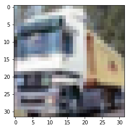

```python
# Let's print out one image in the training set


import matplotlib.pyplot as plt


plt.imshow(x_train[1])
```

```python
# Convert y_train from 2D to 1D

y_train = y_train.reshape(50000)
```

```python
# Check y shape

y_train.shape


# expected output:  (50000,)
```

```
(50000,)
```

```python
y_train[1]

# expected output:  9
```

```
9
```

```python
# Convert y_test from 2D to 1D

y_test = y_test.reshape(10000)
```

```python
y_test.shape

# expected output: (10000,)
```

```
(10000,)
```

```python
# Convert class vectors to one hot format

y_train = tf.keras.utils.to_categorical(y_train, num_classes)
y_test = tf.keras.utils.to_categorical(y_test, num_classes)
```

```python
# Convert data from int to float and normalize it


x_train = x_train.astype('float32')
x_test = x_test.astype('float32')

x_train /= 255
x_test /= 255
```

### 10 pts: Write your code in the cell below to create a CNN model which contains the following types of operations (layers):

- Conv2D
- Activation
- MaxPooling2D
- Flatten
- Dropout
- Dense

### You are also encouraged to create multiple models with different numbers of neurons and layers for performance comparison.

```python
import keras
from keras.models import Sequential
from keras.utils import np_utils
from keras.preprocessing.image import ImageDataGenerator
from keras.layers import Dense, Activation, Flatten, Dropout, BatchNormalization
from keras.layers import Conv2D, MaxPooling2D
from keras.datasets import cifar10
from keras import regularizers
from keras.callbacks import LearningRateScheduler
import numpy as np

weight_decay = 1e-4
model = Sequential()
model.add(Conv2D(32, (3,3), padding='same', kernel_regularizer=regularizers.l2(weight_decay), input_shape=x_train.shape[1:]))
model.add(Activation('elu'))
model.add(BatchNormalization())
model.add(Conv2D(32, (3,3), padding='same', kernel_regularizer=regularizers.l2(weight_decay)))
model.add(Activation('elu'))
model.add(BatchNormalization())
model.add(MaxPooling2D(pool_size=(2,2)))
model.add(Dropout(0.2))

model.add(Conv2D(64, (3,3), padding='same', kernel_regularizer=regularizers.l2(weight_decay)))
model.add(Activation('elu'))
model.add(BatchNormalization())
model.add(Conv2D(64, (3,3), padding='same', kernel_regularizer=regularizers.l2(weight_decay)))
model.add(Activation('elu'))
model.add(BatchNormalization())
model.add(MaxPooling2D(pool_size=(2,2)))
model.add(Dropout(0.3))

model.add(Conv2D(128, (3,3), padding='same', kernel_regularizer=regularizers.l2(weight_decay)))
model.add(Activation('elu'))
model.add(BatchNormalization())
model.add(Conv2D(128, (3,3), padding='same', kernel_regularizer=regularizers.l2(weight_decay)))
model.add(Activation('elu'))
model.add(BatchNormalization())
model.add(MaxPooling2D(pool_size=(2,2)))
model.add(Dropout(0.4))

model.add(Flatten())
model.add(Dense(num_classes, activation='softmax'))
```

```python
# Print model summary

model.summary()
```

```
Model: "sequential_2"
_________________________________________________________________
Layer (type)                 Output Shape              Param #
=================================================================
conv2d_7 (Conv2D)            (None, 32, 32, 32)        896
_________________________________________________________________
activation_7 (Activation)    (None, 32, 32, 32)        0
_________________________________________________________________
batch_normalization_7 (Batch (None, 32, 32, 32)        128
_________________________________________________________________
conv2d_8 (Conv2D)            (None, 32, 32, 32)        9248
_________________________________________________________________
activation_8 (Activation)    (None, 32, 32, 32)        0
_________________________________________________________________
batch_normalization_8 (Batch (None, 32, 32, 32)        128
_________________________________________________________________
max_pooling2d_4 (MaxPooling2 (None, 16, 16, 32)        0
_________________________________________________________________
dropout_4 (Dropout)          (None, 16, 16, 32)        0
_________________________________________________________________
conv2d_9 (Conv2D)            (None, 16, 16, 64)        18496
_________________________________________________________________
activation_9 (Activation)    (None, 16, 16, 64)        0
_________________________________________________________________
batch_normalization_9 (Batch (None, 16, 16, 64)        256
_________________________________________________________________
conv2d_10 (Conv2D)           (None, 16, 16, 64)        36928
_________________________________________________________________
activation_10 (Activation)   (None, 16, 16, 64)        0
_________________________________________________________________
batch_normalization_10 (Batc (None, 16, 16, 64)        256
_________________________________________________________________
max_pooling2d_5 (MaxPooling2 (None, 8, 8, 64)          0
_________________________________________________________________
dropout_5 (Dropout)          (None, 8, 8, 64)          0
_________________________________________________________________
conv2d_11 (Conv2D)           (None, 8, 8, 128)         73856
_________________________________________________________________
activation_11 (Activation)   (None, 8, 8, 128)         0
_________________________________________________________________
batch_normalization_11 (Batc (None, 8, 8, 128)         512
_________________________________________________________________
conv2d_12 (Conv2D)           (None, 8, 8, 128)         147584
_________________________________________________________________
activation_12 (Activation)   (None, 8, 8, 128)         0
_________________________________________________________________
batch_normalization_12 (Batc (None, 8, 8, 128)         512
_________________________________________________________________
max_pooling2d_6 (MaxPooling2 (None, 4, 4, 128)         0
_________________________________________________________________
dropout_6 (Dropout)          (None, 4, 4, 128)         0
_________________________________________________________________
flatten_2 (Flatten)          (None, 2048)              0
_________________________________________________________________
dense_2 (Dense)              (None, 10)                20490
=================================================================
Total params: 309,290
Trainable params: 308,394
Non-trainable params: 896
_________________________________________________________________
```

### 10 pts: Write your code in the cell below for compile, earlystopping and fit. Notice that you should use earlystopping

```python
def lr_schedule(epoch):
    lrate = 0.001
    if epoch > 75:
        lrate = 0.0005
    if epoch > 100:
        lrate = 0.0003
    return lrate

#data augmentation
datagen = ImageDataGenerator(
    rotation_range=15,
    width_shift_range=0.1,
    height_shift_range=0.1,
    horizontal_flip=True,
    )
datagen.fit(x_train)

#training
batch_size = 64



from keras.optimizers import Adam
from keras.callbacks import EarlyStopping, ModelCheckpoint


checkpointer = ModelCheckpoint(filepath='network_best_weight_cnn.hdf5', verbose=0, save_best_only=True)


opt_rms = keras.optimizers.rmsprop(lr=0.001,decay=1e-6)
model.compile(loss='categorical_crossentropy', optimizer=opt_rms, metrics=['accuracy'])
monitor = EarlyStopping(monitor='val_loss', min_delta=1e-3, patience=2, verbose=0, mode='auto')
model.fit_generator(datagen.flow(x_train, y_train, batch_size=batch_size),\
                    steps_per_epoch=x_train.shape[0] // batch_size,epochs=1000,\
                    verbose=1,validation_data=(x_test,y_test),callbacks=[LearningRateScheduler(lr_schedule),checkpointer,monitor])




#Load best weights from model
model.load_weights('network_best_weight_cnn.hdf5')
print("Best Model Loaded....")
```

```
Best Model Loaded....
```

### 10 pts: Write your code in the cell below to print out the Precision, Recall, F1 score, and classification_*report*

### Include your findings in the project report.

```
Accuracy: 0.8223
Averaged F1: 0.819659442013431
              precision    recall  f1-score   support

           0       0.84      0.80      0.82      1000
           1       0.90      0.92      0.91      1000
           2       0.84      0.69      0.75      1000
           3       0.72      0.67      0.69      1000
           4       0.79      0.83      0.81      1000
           5       0.84      0.67      0.75      1000
           6       0.77      0.92      0.83      1000
           7       0.87      0.88      0.87      1000
           8       0.86      0.93      0.89      1000
           9       0.81      0.93      0.87      1000

    accuracy                           0.82     10000
   macro avg       0.82      0.82      0.82     10000
weighted avg       0.82      0.82      0.82     10000

[[801  14  19  11   7   1   7  11  65  64]
 [  6 923   3   1   0   1   2   0  16  48]
 [ 59   7 686  43  61  26  65  20  14  19]
 [ 22   9  30 665  51  77  74  25  21  26]
 [  8   2  28  33 826   6  62  26   6   3]
 [ 10   7  22 141  39 674  48  39   7  13]
 [  9   2  25  15   9   5 915   7   9   4]
 [ 10   2   6  15  50  13  13 875   4  12]
 [ 26  12   1   2   0   0   5   1 929  24]
 [  5  44   1   4   1   0   1   2  13 929]]
Plotting confusion matrix
```

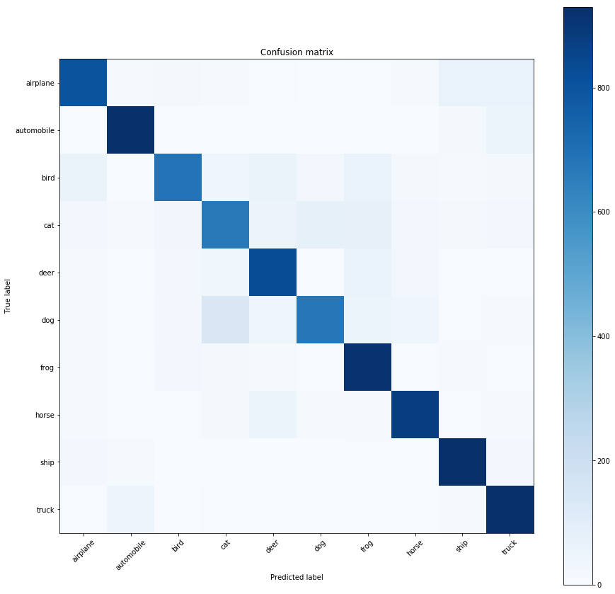

```python
def load_label_names():
    return ['airplane', 'automobile', 'bird', 'cat', 'deer', 'dog', 'frog', 'horse', 'ship', 'truck']


import numpy as np
from sklearn import metrics
from sklearn import svm, datasets
from sklearn.model_selection import train_test_split
from sklearn.metrics import confusion_matrix, classification_report


y_true = np.argmax(y_test,axis=1)
pred = model.predict(x_test)
pred = np.argmax(pred,axis=1)


score = metrics.accuracy_score(y_true, pred)
print('Accuracy: {}'.format(score))


f1 = metrics.f1_score(y_true, pred, average='weighted')
print('Averaged F1: {}'.format(f1))


print(metrics.classification_report(y_true, pred))

# Compute confusion matrix
cm = confusion_matrix(y_true, pred)
print(cm)

print('Plotting confusion matrix')
plt.figure()
plot_confusion_matrix(cm,load_label_names() )
plt.show()
```

## Part II: With Transfer learning

```python
# We load data again.   The data split between train and test sets:

(x_train, y_train), (x_test, y_test) = cifar10.load_data()



print('x_train shape:', x_train.shape)
print('y_train shape:', y_train.shape)

print('x_test shape:', x_test.shape)
print('y_test shape:', y_test.shape)


print(x_train.shape[0], 'train samples')
print(x_test.shape[0], 'test samples')
```

```
x_train shape: (50000, 32, 32, 3)
y_train shape: (50000, 1)
x_test shape: (10000, 32, 32, 3)
y_test shape: (10000, 1)
50000 train samples
10000 test samples
```

### Here we would like to use one pre-trained model called VGG16. For more details on VGG16, please go to https://neurohive.io/en/popular-networks/vgg16/

- VGG16 supports down to 48x48 images as an input. However, the resolution of our images is too low, which is (32, 32) so we need to increase the resolution. This is called upsampling.
- The following cells show you how we can do upsampling for each image to increase its resolution from 32x32 to 64x64 by using the function resize(), which is provided by scikit-image library (https://scikit-image.org/)

```python
import skimage.transform

new_x_train = []

for image in x_train:
  newImage = skimage.transform.resize(image, (64, 64))      # note that resize() also normalizes your image
  new_x_train.append(newImage)


# this code may take about 3 minutes to run
```

```python
new_x_train = np.asarray(new_x_train)
```

```python
new_x_train.shape


# expected output:  (50000, 64, 64, 3)
```

```
(50000, 64, 64, 3)
```

```python
new_x_test = []

for image in x_test:
  newImage = skimage.transform.resize(image, (64, 64))
  new_x_test.append(newImage)


  # this code may take about 2 minutes to run
```

```python
new_x_test = np.asarray(new_x_test)
```

```python
new_x_test.shape


# expected output:  (10000, 64, 64, 3)
```

```
(10000, 64, 64, 3)
```

### 10 pts: Write your code in the cell below to do the following:

- First convert y_train and y_test from 2D to 1D by using reshape() function
- Next apply one-hot encoding to y_train and y_test by using tf.keras.utils.to_categorical() function

```python
y_train.reshape(50000)
y_test.reshape(10000)
y_train = tf.keras.utils.to_categorical(y_train, num_classes)
y_test = tf.keras.utils.to_categorical(y_test, num_classes)
```

```python
# double check shape

print(y_train.shape)
print(y_test.shape)




# expected output:  (50000, 10)
# expected output:  (10000, 10)
```

```
(50000, 10)
(10000, 10)
```

### 5 pts: Now let's load the pre-trained VGG16 model. Write your code in the cell below to add each layer in VGG16 (excluding the top layers) to your new model.

```python
from tensorflow.keras.applications.vgg16 import VGG16

vgg_model = VGG16(weights='imagenet', include_top=False, input_shape=(64, 64, 3))   #  first hidden layer


model = Sequential()


# write your code here

for layers in vgg_model.layers:
  model.add(layers)

# print out the model summary
model.summary()
```

```
Model: "sequential_1"
_________________________________________________________________
Layer (type)                 Output Shape              Param #
=================================================================
block1_conv1 (Conv2D)        (None, 64, 64, 64)        1792
_________________________________________________________________
block1_conv2 (Conv2D)        (None, 64, 64, 64)        36928
_________________________________________________________________
block1_pool (MaxPooling2D)   (None, 32, 32, 64)        0
_________________________________________________________________
block2_conv1 (Conv2D)        (None, 32, 32, 128)       73856
_________________________________________________________________
block2_conv2 (Conv2D)        (None, 32, 32, 128)       147584
_________________________________________________________________
block2_pool (MaxPooling2D)   (None, 16, 16, 128)       0
_________________________________________________________________
block3_conv1 (Conv2D)        (None, 16, 16, 256)       295168
_________________________________________________________________
block3_conv2 (Conv2D)        (None, 16, 16, 256)       590080
_________________________________________________________________
block3_conv3 (Conv2D)        (None, 16, 16, 256)       590080
_________________________________________________________________
block3_pool (MaxPooling2D)   (None, 8, 8, 256)         0
_________________________________________________________________
block4_conv1 (Conv2D)        (None, 8, 8, 512)         1180160
_________________________________________________________________
block4_conv2 (Conv2D)        (None, 8, 8, 512)         2359808
_________________________________________________________________
block4_conv3 (Conv2D)        (None, 8, 8, 512)         2359808
_________________________________________________________________
block4_pool (MaxPooling2D)   (None, 4, 4, 512)         0
_________________________________________________________________
block5_conv1 (Conv2D)        (None, 4, 4, 512)         2359808
_________________________________________________________________
block5_conv2 (Conv2D)        (None, 4, 4, 512)         2359808
_________________________________________________________________
block5_conv3 (Conv2D)        (None, 4, 4, 512)         2359808
_________________________________________________________________
block5_pool (MaxPooling2D)   (None, 2, 2, 512)         0
=================================================================
Total params: 14,714,688
Trainable params: 14,714,688
Non-trainable params: 0
_________________________________________________________________
```

### 5 pts: Write your code in the cell below to freeze the weights in each layer in the new model

```python
for layer in model.layers:
  layer.trainable = False
```

### 5 pts: Write your code in the cell below to add some "Dense" layers as top layers.

- Donot forget the output layer
- Choose the right activation fucntion for the output layer

```python
model.add(Flatten())


# Add some "Dense" layers here, including output layer
model.add(Dense(128, activation='relu'))
model.add(Dense(10, activation='softmax'))
```

### 5 pts: Write your code in the cell below for compile and fit. Notice that you should use earlystopping

```python
from tensorflow.keras.optimizers import Adam
from tensorflow.keras.callbacks import EarlyStopping, ModelCheckpoint


checkpointer = ModelCheckpoint(filepath='TL.hdf5', verbose=0, save_best_only=True)


for i in range(2):
  model.compile(loss=tf.keras.losses.categorical_crossentropy, optimizer=Adam(lr=0.001, decay=1e-6), metrics=['accuracy'])
  monitor = EarlyStopping(monitor='val_loss', min_delta=1e-3, patience=2, verbose=0, mode='auto')
  model.fit(new_x_train, y_train,validation_data=(new_x_test,y_test),callbacks=[monitor,checkpointer],verbose=1,epochs=1000)



#Load best weights from model
model.load_weights('TL.hdf5')
print("Best Model Loaded....")
```

```
Train on 50000 samples, validate on 10000 samples
Train on 50000 samples, validate on 10000 samples
Best Model Loaded....
```

### 5 pts: Write your code in the cell below to print out the Precision, Recall, F1 score, and classification_report

### Include your findings in the project report.

```
Accuracy: 0.7007
Averaged F1: 0.697365570010261
              precision    recall  f1-score   support

           0       0.78      0.74      0.76      1000
           1       0.70      0.88      0.78      1000
           2       0.64      0.64      0.64      1000
           3       0.59      0.42      0.49      1000
           4       0.65      0.68      0.66      1000
           5       0.61      0.63      0.62      1000
           6       0.67      0.77      0.71      1000
           7       0.77      0.73      0.75      1000
           8       0.79      0.82      0.80      1000
           9       0.83      0.70      0.76      1000

    accuracy                           0.70     10000
   macro avg       0.70      0.70      0.70     10000
weighted avg       0.70      0.70      0.70     10000

[[741  31  53  11  27   3  15  16  84  19]
 [ 12 875   5   6   5   7  13   6  31  40]
 [ 49  17 636  33  85  45  98  24  11   2]
 [ 17  44  62 421  53 208 107  43  18  27]
 [ 14  18  63  47 678  37  73  49  16   5]
 [  8  25  75  96  50 631  46  50   5  14]
 [  5  27  43  45  49  40 771   6  12   2]
 [ 13  14  45  24  78  57  15 728   8  18]
 [ 55  48  10  11   9   6  11   7 821  22]
 [ 39 159   8  16   8   8   9  14  34 705]]
Plotting confusion matrix
```

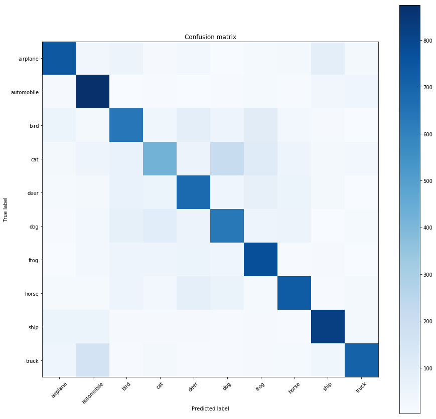

```python
def load_label_names():
    return ['airplane', 'automobile', 'bird', 'cat', 'deer', 'dog', 'frog', 'horse', 'ship', 'truck']


import numpy as np
from sklearn import metrics
from sklearn import svm, datasets
from sklearn.model_selection import train_test_split
from sklearn.metrics import confusion_matrix, classification_report


y_true = np.argmax(y_test,axis=1)
pred = model.predict(new_x_test)
pred = np.argmax(pred,axis=1)


score = metrics.accuracy_score(y_true, pred)
print('Accuracy: {}'.format(score))


f1 = metrics.f1_score(y_true, pred, average='weighted')
print('Averaged F1: {}'.format(f1))


print(metrics.classification_report(y_true, pred))

# Compute confusion matrix
cm = confusion_matrix(y_true, pred)
print(cm)

print('Plotting confusion matrix')
plt.figure()
plot_confusion_matrix(cm,load_label_names() )
plt.show()
```

### 5 pts: Write your code in the cell below to show 3-5 images in the test set as well as their true labels and their labels predicted by your created model

### Include your findings in the project report.

```python
def load_label_names():
    return ['airplane', 'automobile', 'bird', 'cat', 'deer', 'dog', 'frog', 'horse', 'ship', 'truck']
```

```python
from PIL import Image

names = load_label_names()
for i in range(10):
  display(Image.fromarray(x_test[i+10], 'RGB'))
  print("Predictions: {}      True : {}".format(names[pred[i+10]],names[y_true[i+10]]))
  #print("Predictions: {}      True : {}".format(pred[i+10],y_true[i+10]))
```

[output not shown]

```
Predictions: airplane      True : airplane
```

```
Predictions: truck      True : truck
```

```
Predictions: dog      True : dog
```

```
Predictions: horse      True : horse
```

```
Predictions: truck      True : truck
```

```
Predictions: frog      True : ship
```

```
Predictions: dog      True : dog
```

```
Predictions: horse      True : horse
```

```
Predictions: ship      True : ship
```

```
Predictions: frog      True : frog
```